# Impact of COVID-19 on critical care research

This report summarizes the results of an ongoing study focused on understanding the impact of the COVID-19 pandemic on Critical Care research. It includes data submitted by 54 ICUs between 2020-03-09 and 2020-03-23.

## Participating centres

### ICU location

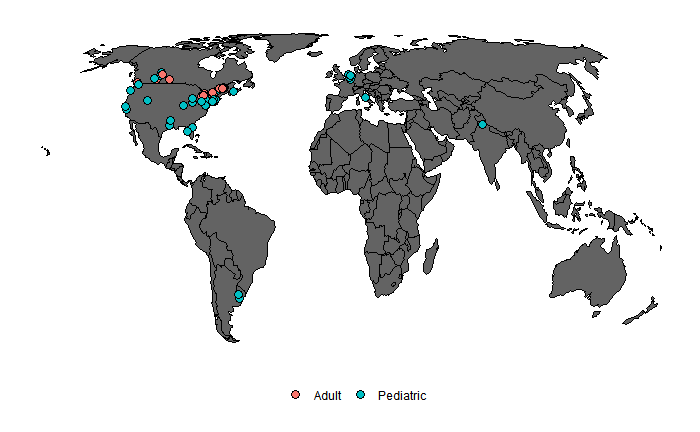

| Country | ICUs |
| --- | --- |
| CAN | 25 |
| USA | 20 |
| NLD | 5 |
| ARG | 1 |
| IND | 1 |
| ITA | 1 |
| URY | 1 |

### Date surveys completed

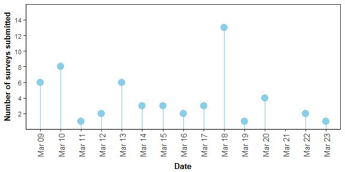

### ICU population

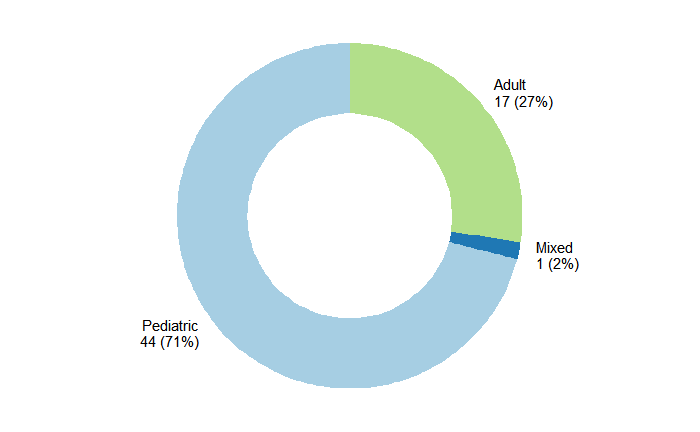

### Centre type

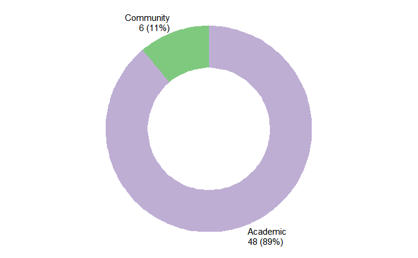

## COVID-19

**Are there any patients in your hospital with CONFIRMED COVID-19?** (n = 54)

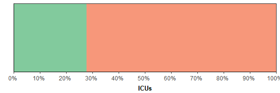

**Are there any patients in your ICU with CONFIRMED COVID-19?** (n = 54)

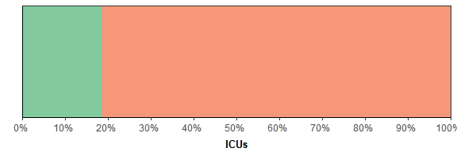

**Is your ICU currently enrolling patients in any COVID-19 specific studies?** (n = 48)

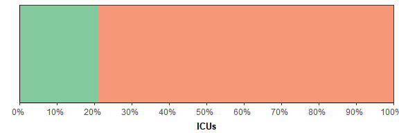

**Is your REB/IRB prioritizing approval or willing to expedite approval of COVID-19 protocols?** (n = 55)

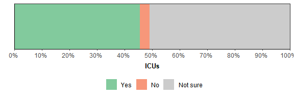

## Impact on research

**Because of COVID-19 or preparation for it, has your ICU:**

**Suspended recruitment for any studies?** (n = 55)

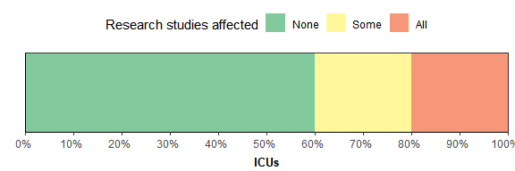

| Comments |
| --- |
| We have not yet, but once we have a case we will only recruit for COVID, influenza, and ILI studies |
| Our nurse coordinator is quarantined 14 days |
| research interns not permitted on campus, which is main workforce for data collection and enrollment. |
| Any study involving direct interaction with patients |
| all non COVID-19 studies are suspended. research personnel not allowed on site in the hospital |
| Every one who doesn’t give patient-care must work at home |
| Reason is limiting (research) personell |
| I believe one flu study with a different PI is still enrolling. Another PI (me) of a different study suspended all in-hospital recruitment for an observational study as I deemed the risk to research p… |
| All non covid19 related studies are suspended |
| RCT depending of research pharmacy |
| No studies so as not to risk exposure |
| As advised by the Dutch medical and ethical committees |
| There are two observational studies targeted to learning more about COVID-19. |
| No research staff in the institution (mandatory telework) so some studies which require a research coordinator are paused. |
| Not collecting intubated patient samples |
| All research has been suspended at ### PICU |
| All research related activities have been suspended. |
| Not suspended for COVID-19 studies or studies conducted by physicians |
| Not enrolling patients which would require the use of PPE for the research staff to collect samples |

**Modified recruitment for current studies?** (n = 55)

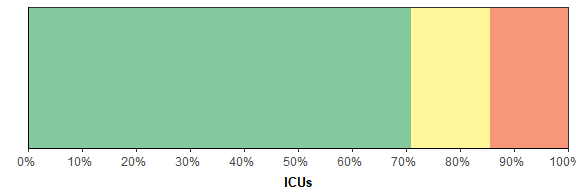

| Comments |
| --- |
| If PPE is needed we are not recruiting for studies except for those mentioned above |
| Not enrolling in a drug trial that uses deferred consent |
| Reduced human ressources |
| same as above |
| as above |
| SHIPSS will not be enrolling COVID patients, and COVID patients can not go into the HFOV arm of a study |
| no enrolment. ongoing screening |
| one who doesn’t give patient-care must work at home |
| no icu studies are recruiting/screening |
| Not approaching suspected or confirmed COVID to conserve PPE |
| Via phone, via email, and samples will be collected by specially trained PIs, fellows, and nurses. |
| we are still screening and documenting potential subjects, no enrollment activity is happening |
| All research related activities have been suspended. |
| Decreased research assistant presence in-hospital |

**Delayed the initiation of new (non-COVID-19) studies?** (n = 54)

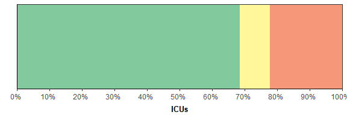

| Comments |
| --- |
| Capacity to initiate a new study |
| HREB prioritizing COVID studies right now |
| postponing all new IRB submissions in antipation of depleted workforce |
| We are no longer allowed to initiate non-COVID studies for the time being |
| studies ready to start where put on hold |
| at this moment no go for new projects |
| all icu studies whether new or ongoing are on hold |
| Lead investigator at a different site delayed initiation |
| a couple of new studies have been postponed |
| unable to work on current research. Time limited. |
| ALl current ongoing contracting and IRB is on hold |
| ### PICU is not enrolling subjects for any studies |
| for decision of promoter of multicentric study |

**Enrolled MORE patients in studies because of increased patient volume?** (n = 54)

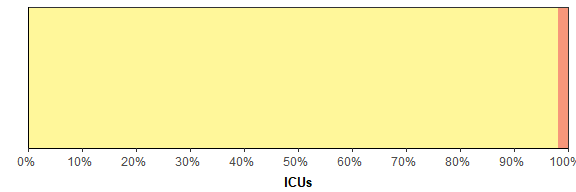

| Comments |
| --- |

**Enrolled FEWER patients in studies because of increased patient volume?** (n = 54)

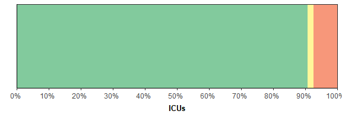

| Comments |
| --- |
| no COVID Patients yet and all other studies are put on hold |
| See above, research studies suspensed to limit people that are not directly related to patiënt care in the PICU |
| fewer surgeries, so less bleeding events. |

**Changed the approach to co-enrollment in studies?** (n = 54)

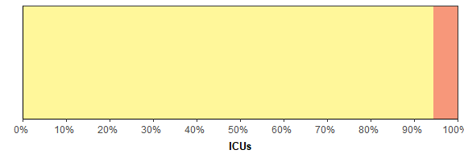

| Comments |
| --- |
| We amennded original variables to include COVID19 identification |
| See above |
| as number of patients has increased, less time available to consent for studies. |

**Changed or stopped collection of biologic samples?** (n = 55)

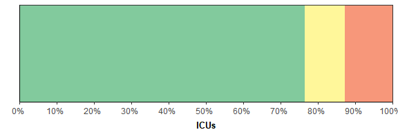

| Comments |
| --- |
| Delayed collection by 1 day |
| may not have access to current lab, and research interns previously did sample collection and transport. Will probably resume next week once new mechanisms put into place. |
| as part of studie mentioned above, but will collect blood for PK |
| Tracheal aspirates only processed half day |
| Biorepository Studies |
| sputum samples are not being collected |
| ### PICU has stopped enrollment and no biologic samples have been collected |
| We have stopped all specimen collection, our first move was to hault respiratory samples, followed quickly by a total shut down. |
| PROSPECT study has suspended bio sample collection |
| actually there are no studies with blood samples collection |
| Research personell not approaching patients or collecting samples that would require them to use PPE |

**Other effects on studies in your ICU?** (n = 52)

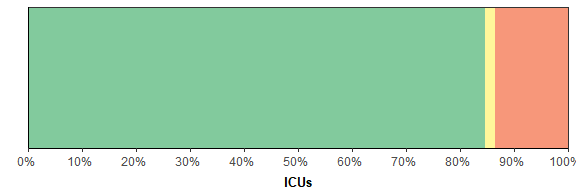

| Comments |
| --- |
| Less human ressources; less students coming to work |
| study personnel with license are asked to participate in clinical care. |

## Reasons for impact

**Because of COVID-19 or preparation for it, how much of an effect have the following had on research in your ICU?**

**Research staff WITH a clinical background are needed to work clinically** (n = 55)

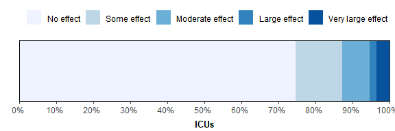

**Research staff WITHOUT a clinical background are needed to help with hospital activities** (n = 55)

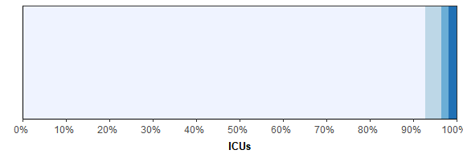

**Research staff are concerned about their safety working during outbreak** (n = 55)

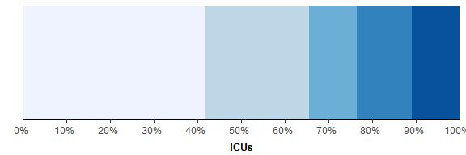

**Not enough research staff for increased number of COVID-19 studies** (n = 55)

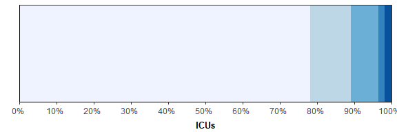

**Not enough research staff for increased number of eligible patients** (n = 55)

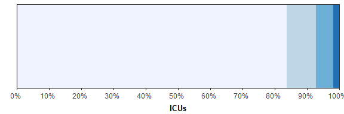

**Infection control policies limiting research staff access to the ICU** (n = 54)

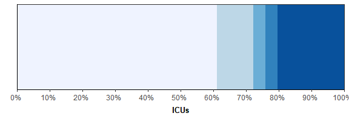

**Infection control policies limiting research staff access to patients with confirmed or suspected COVID-19** (n = 55)

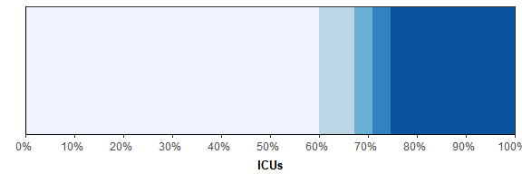

**Clinical staff are too busy to complete research-related tasks** (n = 55)

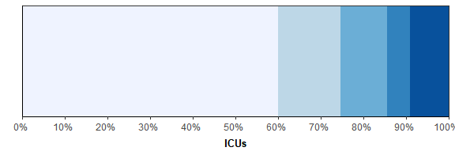

**COVID-19 specific research is prioritized over other research** (n = 55)

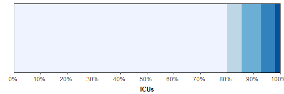

| Comments |
| --- |
| Presumably if we have a COVID-19 case (or suspected), research personnel will not have access to patient to approach for enrolment. |
| Not yet |
| not yet! |
| No. |
| Co-op student involved in one particular trial will be taking an extended period of time off due to secondary schools being closed for additional 2 weeks. May or may not disrupt trial as others are av… |
| No |
| Many emails related to COVID19 and COVID19 research are adding to workload (some effect) |
| none as of yet |
| We have not seen an influx of COVID-19 patients yet. |
| Our 12 research interns are the workforce that does the vast majority of enrolling and data collecting. They are undergraduate and graduate students of the university and not permitted to enter the ho… |
| we are doing our best to mitigate exposure to patients and research staff. Therefore all observational studies new enrollments on hold |
| Stress on the bedside staff with all the changes to their personal lives. When schools closed you felt staff stress increase. There has been less notification of eligible patients by bedside staff and… |
| Less time/attention span for my own research activities as PI (revision of papers, managerial activities, e.g. talking to lawyers for contracts) |
| Not for now |
| None |
| With regard to question 3, we never got that far (ie we never got as far as the research personnel expressing concerns to me) because I suspended enrollment the day after we had our first COVID case. … |
| all research is on hold unless it is covid19 related research which as of now we are not conducting |
| No |
| Decreased ability to start up new non-COVID related studies for now. |
| All Research Coordinators have been deemed non-essential and sent home to work from home for two weeks; we will reevaluate at the end of March. |
| ### PICU has suspended subject enrollment and sample collection, processing and shipping. All study coordinators and research assistants are working remotely from home. The focus is to complete all ba… |
| Not yet - but we anticipate broad changes as the pandemic worsens locally. |
| no |

## Other comments

**Are there other questions you think we should add to the next month’s survey?**

| Other questions to ask |
| --- |
| Though soft, I would be curious about bedside staff willingness to participate- overly stressed or burned out bedside staff are going to be less eager to help with research. |
| not at this point |
| Staff stress levels, number of staff off on isolation. |
| possibility for others to collaborate on starting/ongoing studies |

**Do you have other information you think would be important for us to know?**

| Comments |
| --- |
| no |
| We do not currently have any active cases in Ottawa, so there has not been any effect on research to date. However, I am aware of plans in place to suspend research should ### see a number of cases, a… |

## To join this study

On behalf of the Canadian Critical Care Trials Group and Canadian Critical Care Research Coordinators group, we invite your site to participate in a short longitudinal survey of the effects of COVID-19 on critical care research.

Use this link to send us the name and email of the person who will complete the survey on behalf of your centre: http://bit.ly/3aNqo8Z  
They’ll receive a separate email with the survey within 24 hours and will get:  
1) A 3-question survey about your ICU  
2) A short (<10 min) monthly survey about the impact of COVID-19 on research in your ICU

## About this study

**Background:** As we prepare for and manage COVID-19 patients in our ICUs, we realize both the importance of studying this disease and our role as global leaders in critical care research. From our experiences with SARS and H1N1, we also know that COVID-19 may both enhance and constrain current critical care research projects.

**Objectives:** The aims of this study are to:  
1. Characterize current research activities in ICUs  
2. Describe the effects of COVID-19 (and preparations) on research in ICUs, specifically to: identify new research started due to COVID-19; describe any impact on existing research activities; and identify COVID-19 hospital or ICU policies affecting research.

**Methods:** If you agree for your site to participate, you or your delegate will receive:  
• A link to a single, brief survey (3 questions) about your ICU  
• A link to a short (<10 minutes) survey about the impact of COVID-19 on research in your ICU. It will be sent on the first of the month for the duration of the COVID-19 outbreak.  
• A report summarizing the results after each monthly survey

**Ethics and privacy:** This study has been reviewed by the Hamilton Integrated Research Ethics Board. Participation is of course voluntary and submitting data implies your consent to participate . You can stop participating at any time and prior to analysis you can withdraw any data from your centre. We will not publish any site or personal identifying information without your express consent.

Thank you, and we welcome any suggestions for adapting and updating this survey as events in this pandemic unfold.

**Mark Duffett**, RPh PhD  
Departments of Pediatrics and Health Research Methods, Evidence, and Impact, McMaster University, Hamilton, Canada. duffetmc@mcmaster.ca, @M_Duffett

**Michelle Kho**, PT PhD  
School of Rehabilitation Science, McMaster University, Hamilton, Canada. khome@mcmaster.ca, @khome